# OSM arrays: Import camera data, covariates, and calculate independent detections

# 3. Import OSM deployment data

This deployment data is confirmed as correct. It does NOT account for snow cover, which we will do manually below using the image data.

```r
osm_deploy <- list.files(path="./data/raw/",
                               pattern="OSM_deployment_2",
                               full.names = TRUE) %>%
      map_dfr(.,
          ~read_csv(.x,
                   col_types = cols(array = col_factor(),
                                    site = col_factor(),
                                    start_date = col_datetime(format = "%Y-%m-%d"),
                                    end_date = col_datetime(format = "%Y-%m-%d"),
                                    camera_failure_details = col_character()
                                    )
          ) %>%

            mutate(
              site = gsub("-", "_", site) %>% # First, replace the hyphen with underscore
                gsub("_0+", "_", .) %>% # Then, remove leading zeros after the underscore
                gsub(" ", "", .) %>% # Then, remove any spaces
                gsub("LU0", "LU", .) %>% # Remove leading zeros from LU names for consistency
                as.factor(.), # Then, convert back to factor
               ) %>%

            select(-array) %>%

            separate_wider_delim(site,
                                 delim = '_',
                                 names = c('array', 'camera'),
                                 cols_remove = FALSE) %>%

            # specify format of new columns
            mutate(
              array = as.factor(array),
              camera = as.factor(camera)
              )
      )
```

Plot it out. It all looks good to me!

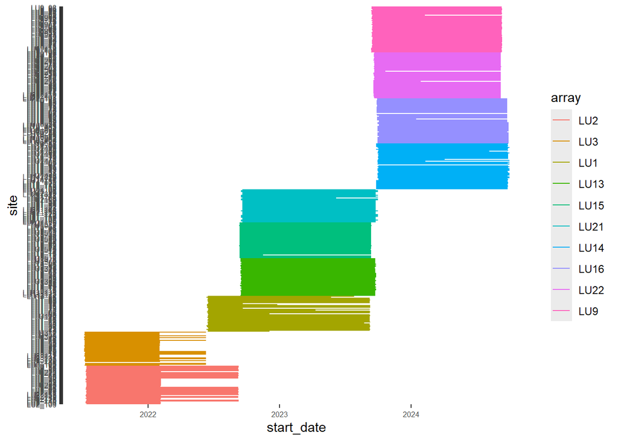

```r
# Inspect the deployment data to make sure it all looks reasonable
ggplot(osm_deploy, aes(color = array))+

  geom_segment(aes(x = start_date,
                   xend = end_date,
                   y = site,
                   yend = site)) +

  theme(axis.text = element_text(size = 6))
```

List of dates:

```r
osm_operating <- osm_deploy %>%

  drop_na(start_date, end_date) %>%

  rowwise() %>%

  # create a list sequence of dates for each site from the first to the last day of operability
  mutate(date = list(seq(from = date(start_date), to = date(end_date), by="day"))) %>%

  unnest(date) %>%

  select(array, camera, site, date)
```

We also need to modify the OSM operating dataframe to account for days where the camera was fully covered by snow or otherwise obstructed (cases where `cameramalfunction == *'Fully obscured'*`). Let’s identify those from the raw timelapse data and remove them from `osm_operating`.

```r
osm_obscured <- osm_image %>%

  filter(cameramalfunction == 'Fully obscured') %>%

  mutate(date = as.Date(datetime)) %>%

  select(array, camera, site, date) %>%

  distinct()
```

Let’s remove those dates:

```r
osm_operating <- osm_operating %>%

  anti_join(osm_obscured)
# Save the operating days file
#write_csv(osm_operating, "./data/raw/OSM_operating_days.csv")
```

Write the file:

```r
write_csv(osm_operating, "./data/processed/OSM_operating_2021-2023.csv")
rm(osm_deploy)
```

# 4. Import OSM covariate data

This has already been cleaned, grouped, and inspected in the OSM_20XX-20XX repositories on the ACME GitHub, see those for details. The protocol established here for grouping and removing HFI and Landcover variables will be followed by the other arrays in this project for consistency.

```r
osm_covs <- read_csv("./data/raw/OSM_covariates_grouped_2021_2022_2023.csv",
                     col_types = cols(site = col_factor(),
                                      array = col_factor(),
                                      .default = col_number())
                     ) %>%

              mutate(
              site = gsub("-", "_", site) %>% # First, replace the hyphen with underscore
                gsub("_0+", "_", .) %>% # Then, remove leading zeros after the underscore
                gsub(" ", "", .) %>% # Then, remove any spaces
                gsub("LU0", "LU", .) %>% # Remove leading zeros from LU names for consistency
                as.factor(.), # Then, convert back to factor
               ) %>%

            select(-array) %>%

            separate_wider_delim(site,
                                 delim = '_',
                                 names = c('array', 'camera'),
                                 cols_remove = FALSE) %>%

            # specify format of new columns
            mutate(
              array = as.factor(array),
              camera = as.factor(camera)
              )
```

We may want each buffer to have it’s own column for each variable (e.g. create a wide format of this data) for modeling purposes, we can do that with the `pivot_wider()` function.

```r
# we also may want to pivot wider so that each column is for a different buffer for modeling purposes, we can use pivot wider to do this

osm_covs_wide <- osm_covs %>%

  # pivot wider was not collapsing the data very well with the camera and array variables present.
  # let's remove them first.
  select(site, buff_dist, harvest:osm_industrial) %>%

  # wide data
  pivot_wider(names_from = buff_dist,
              values_from = c(harvest:osm_industrial)) %>%

  # let's re-add the array and camera columns that we previously lost.
  # this code is redundant but seems to help `pivot_wider` do its job.
  separate_wider_delim(site,
                       delim = '_',
                       names = c('array',
                                 'camera'),
                       cols_remove = FALSE) %>%

  # specify format of new columns
  mutate(array = as.factor(array),
         camera = as.factor(camera))
```

# 5. Import OSM coordinates

We will get these from the site deployment datasheets, originally sourced from the NetDrive.

```r
osm_coords <- list.files(path="./data/raw/",
                               pattern="OSM_Deployment_Site_",
                               full.names = TRUE) %>%
      map_dfr(.,
          ~read_csv(.x,
                   col_types = cols(Array = col_factor(),
                                    Site = col_factor(),
                                    Lat = col_number(),
                                    Long = col_number())
                   ) %>%

            set_names(names(.) %>% tolower()) %>%

            select(-array) %>%

            mutate(
              site = gsub("-", "_", site) %>% # First, replace the hyphen with underscore
                gsub("_0+", "_", .) %>% # Then, remove leading zeros after the underscore
                gsub(" ", "", .) %>% # Then, remove any spaces
                gsub("LU0", "LU", .) %>% # Remove leading zeros from LU names for consistency
                as.factor(.), # Then, convert back to factor
               ) %>%

            separate_wider_delim(site,
                                 delim = '_',
                                 names = c('array', 'camera'),
                                 cols_remove = FALSE) %>%

            # specify format of new columns
            mutate(
              array = as.factor(array),
              camera = as.factor(camera)
              ) %>%

            select(array, camera, site, lat, long)
      )
```

Get UTM coordinates (NAD83 UTM 12N):

```r
# assuming lat/long was extracted in NAD83
osm_coords <- st_as_sf(osm_coords, coords = c("long", "lat"), crs = 4269) %>%

  mutate(long = st_coordinates(.)[,1],
         lat = st_coordinates(.)[,2]) %>%

  st_transform(osm_coords, crs = 26912) %>%

  mutate(easting_12n = st_coordinates(.)[,1],
         northing_12n = st_coordinates(.)[,2]) %>%

  st_drop_geometry(.)

st_crs(osm_coords)
```

```
## Coordinate Reference System: NA
```

Join the coordinates to the covariate data.

```r
osm_covs_wide <- osm_coords %>%

  left_join(osm_covs_wide, by = c('array', 'camera', 'site'))
```

Final check:

```r
# also, just to confirm: there is covariate data for all sites in the detection data.
setdiff(unique(osm_indet$site),
        unique(osm_covs_wide$site))
```

```
## character(0)
```

```r
# covs were extracted for two extras site that we don't rly care about. LU3_106 has no data, and neither does LU14_57.
# I'm not sure why it's in the coordinate file for LU03.
setdiff(unique(osm_covs_wide$site),
        unique(osm_indet$site))
```

```
## [1] "LU3_106" "LU14_57"
```

We have covariates for all our detection data which is what matters. The extra covariates do not matter and will be filtered out later when we join our data. If those sites’ data ever turn up on an old SD card or something, this means we’ll be prepared with the cov data.

Save the file:

```r
write_csv(osm_covs_wide, "./data/processed/OSM_covariates_2021-2023.csv")
```